# ggplot2

Jong-June Jeon

May, 2018

## visualization tool: ggplot

## introduction

```
* ggplot은 데이터 시각화에 사용되는 여러가지 도구들을 객체(object)로 정리함.

* ggplot의 사용방법은 평면에 시각화 도구가 표현된 셀로판지를 덮어가면서
그림을 완성해나가는  방식
        + `ggplot()` 함수는 데이터를 ggplot 객체로 만든다.
        + `ggplot()` 함수는 캔버스를 만드는 작업에 비유할 수 있다.
        +  여러가지 `geom_()` 함수를 통해 데이터를 캔버스에 그린다.
        +  `ggplot()` 혹은  `geom_()` 내에는 `aes` 옵션이 있는데 그림을
        그리는 방법을 알려 주게 된다.
```

## introduction

- 어떤 정보를 전달 할 것인가?
- 2차원상에 표현된 그래프가 어떤 정보를 전달 할 수 있나?
- 정보의 양과 전달의 효과성 사이에서 선택 문제
- 좋지 않은 그래프는 무엇인가?

## Data set (mammals sleep dataset)

- 포유동물의 수면 시간 분석 분석
  - 83 rows, 11 variabels
  - bodywt : 몸무게 (kg)
  - sleep_total : 총 자는 시간 (hours)
  - vore : 동물 종류 (육식, 채식, 잡식)

## Data set (mammals sleep dataset)

```r
head(msleep[,c(3, 6 ,11)])
```

```
## # A tibble: 6 x 3
##   vore  sleep_total   bodywt
##   <chr>       <dbl>    <dbl>
## 1 carni       12.1   50.0
## 2 omni        17.0    0.480
## 3 herbi       14.4    1.35
## 4 omni        14.9    0.0190
## 5 herbi        4.00 600.
## 6 herbi       14.4    3.85
```

- 체중과 수면시간의 관계를 살펴보자

## geom_point()

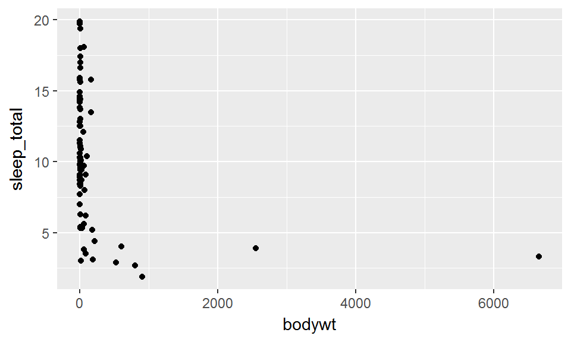

```
*  `bodywt`에 변수 스케일이 너무커 관계 파악이 어려워 보인다.
    + log-transformation 이 유용할 것으로 보인다.
```

## geom_point()

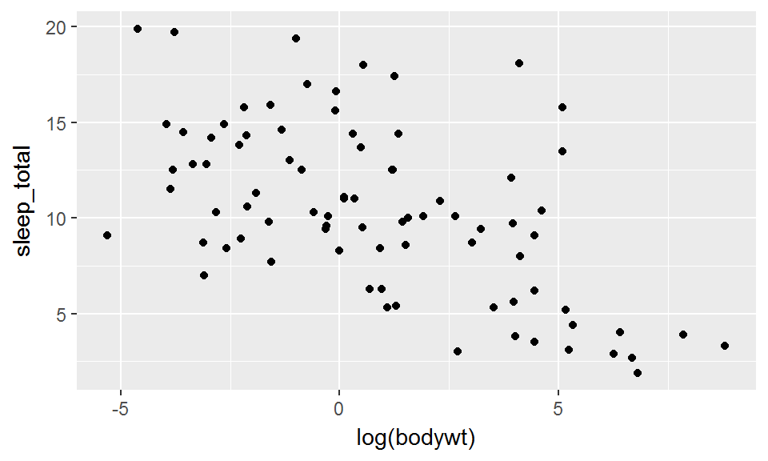

```
* `log(bodywt)`와 `sleep_total`은 선형관계가 보인다.
```

## geom_point()

- 다른정보도 있는데… (육식, 채식, 잡식)

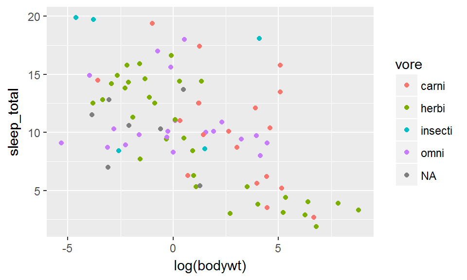

## geom_point()

- 따로 그리자 … (육식, 채식, 잡식)

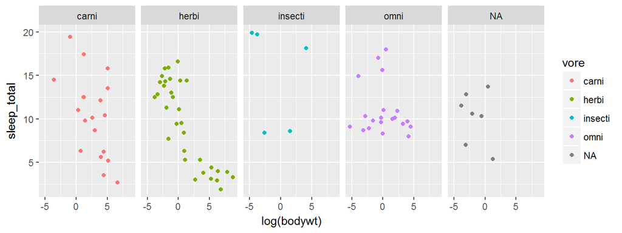

## geom_point()

- ggplot의 Visualization 절차
  - 캔버스 만들기 (ggplot)
    - 가로, 세로 정해주기
  - 점을 찍기 (geom_point)
    - 점에 대하 정보를 줄 수 있다.

## geom_point()

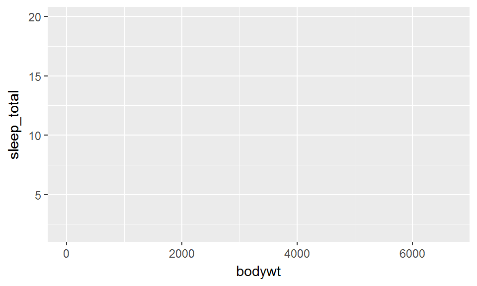

```r
ggplot(data = msleep, aes(x = bodywt, y = sleep_total))
```

```
* `ggplot()` 은 캔버스를 그려준다.
    +  `msleep` 데이터를 사용한다.
    + `aes()` 옵션에 x 축과 y축에 사용할 변수가 지정되어 있다.
```

## geom_point()

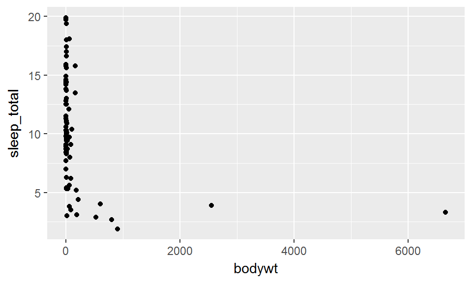

```r
ggplot(data = msleep, aes(x = bodywt, y = sleep_total)) + geom_point()
```

```
* `+ geom_point()`  를 통해 이미 만들어진 캔버스에 점이 찍히게 된다.
```

## geom_point()

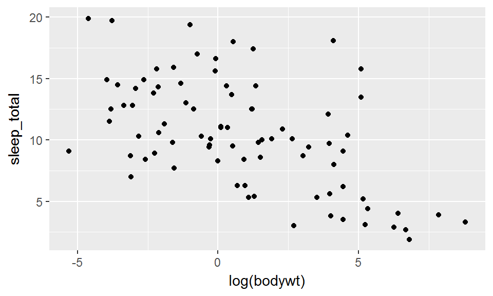

```r
ggplot(data = msleep, aes(x = log(bodywt), y = sleep_total)) + geom_point()
```

```
* `aes()` 옵션에 x축을 `log(bodywt)`로 설정: 즉 처음부터 캔버스의 가로와
세로를 다르게 잡은 것이다. 이 캔버스에 맞춰 geom_point가 점을 찍는다.
```

## geom_point()

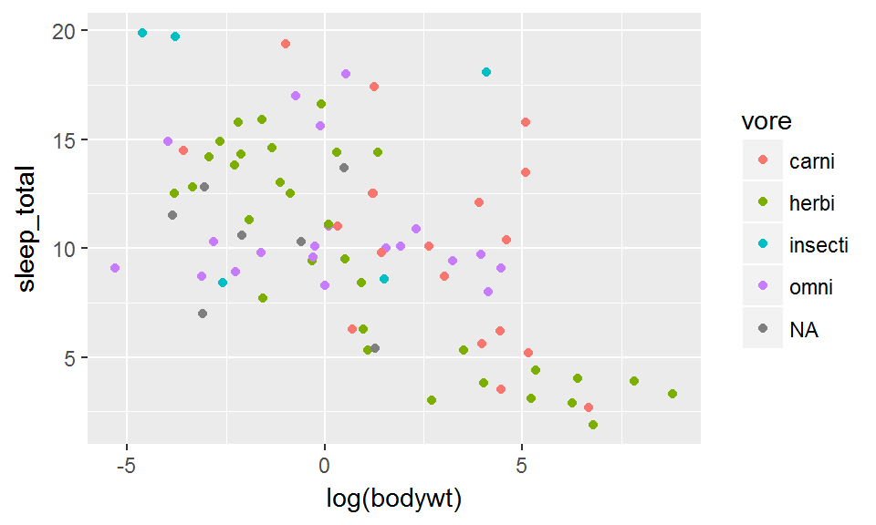

```r
scatterplot = ggplot(data = msleep,
              aes(x = log(bodywt), y = sleep_total, col = vore)) +
              geom_point()
scatterplot
```

```
* `aes` 옵션에 `col` 에 범주형 변수인 `vore` 를 지정하자.
    + 점들이 `vore`가진 값에 따라 다른 색상을 가질 것이다.

* 생성한 그림 객체는 변수로 저장할 수 있다.
```

## geom_point()

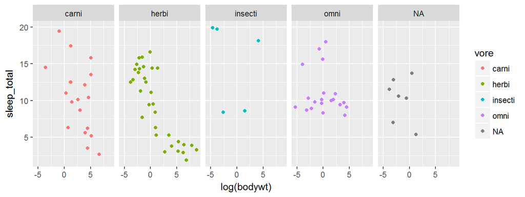

```r
scatterplot1 = ggplot(data = msleep,
              aes(x = log(bodywt), y = sleep_total, col = vore)) +
              geom_point() + facet_grid(~vore)
scatterplot1
```

```
* facet_grid는 캔버스를 여러개를 쓴다는 것이다.
안쪽에 (~vore) 라고 되어 있는 것은 캔버스를 옆으로 늘어놓을 것이고
vore 있는 값에 따라 따로 그림을 그린다는 뜻이다.
```

## geom_point()

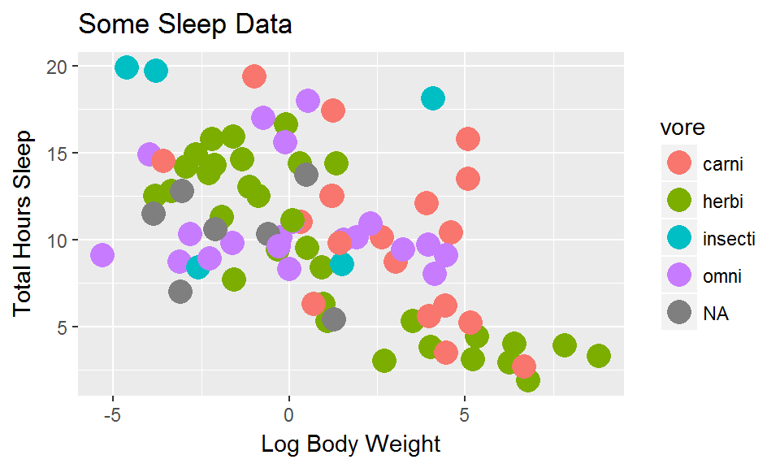

```r
Scatterplot <- scatterplot + geom_point(size = 5) +
    xlab('Log Body Weight') +  ylab("Total Hours Sleep") +
    ggtitle('Some Sleep Data')
Scatterplot
```

## geom_point()

- scatterplot을 가져와
  - point의 size = 5로 설정
  - xlab : x축 이름, ylab = y축 이름 할당
  - ggtitle : 그래프 전체 이름 할당
- Scatterplot에 저장

## geom_point()

- 포유동물의 종류에 따라 수면시간을 비교하자.
- 가로축을 포유동물의 종류
- 세로축을 수면시간

## geom_point()

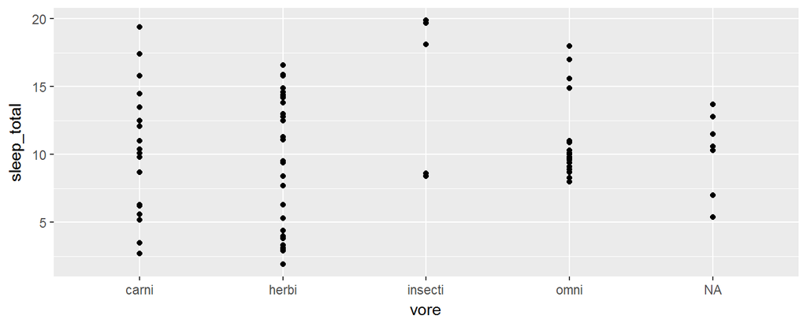

```
* 점이 많이 겹쳐서 데이터가 많은 곳끼리 비교가 잘 안된다.
* 점을 좌우로 조금만 흔들면 비교가 쉬울 것 같다.
```

## geom_jitter()

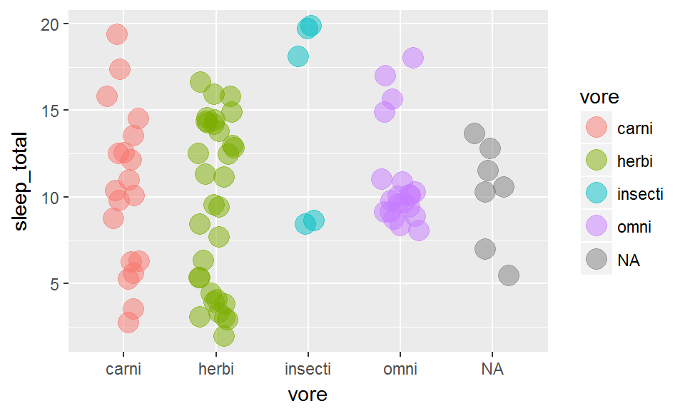

## geom_point()

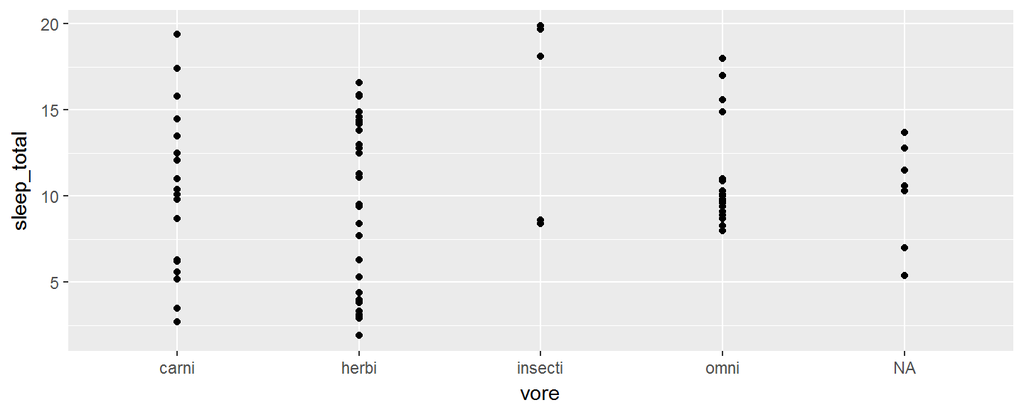

```r
stripchart <- ggplot(msleep, aes(x = vore, y = sleep_total)) + geom_point()
stripchart
```

```
* `ggplot`  객체에 x 축이 범주형 변수로 설정이 되어 있어도 `geom_point()`로
표현할 수 있다.
```

## geom_jitter()

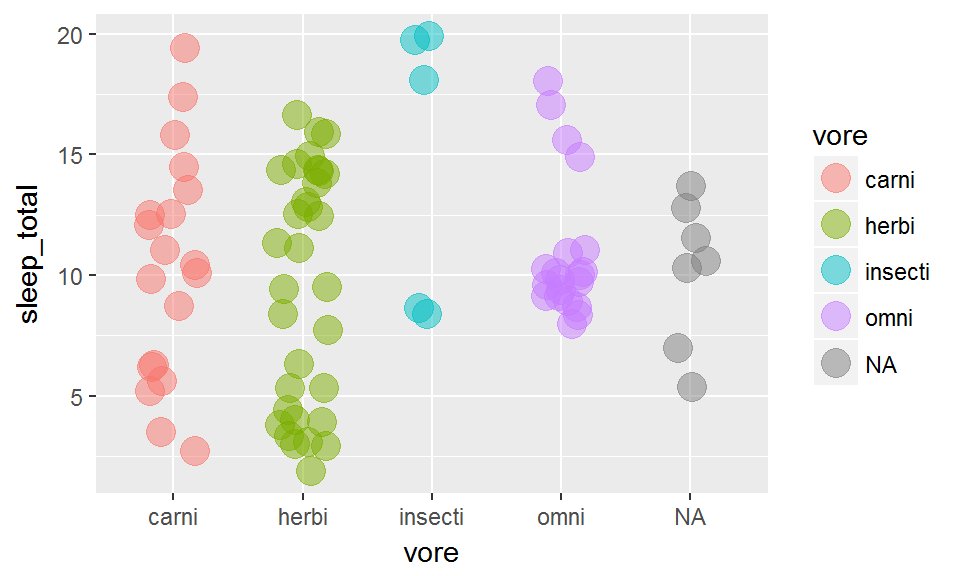

```r
stripchart <- ggplot(msleep, aes(x = vore, y = sleep_total, col = vore)) +
  geom_jitter(position =  position_jitter(width = 0.2),
              size = 5, alpha = 0.5)
stripchart
```

* geom_jitter + poistion : 점의 위치 지정 (양쪽 0.2씩) + 점 크기 = 5로 할당 + 투명도 0.5

## geom_line

```r
dane <- data.frame(mylevels=c(1,2,5,9), myvalues=c(2, 5, 3, 4))
head(dane)
```

```
##   mylevels myvalues
## 1        1        2
## 2        2        5
## 3        5        3
## 4        9        4
```

## geom_line

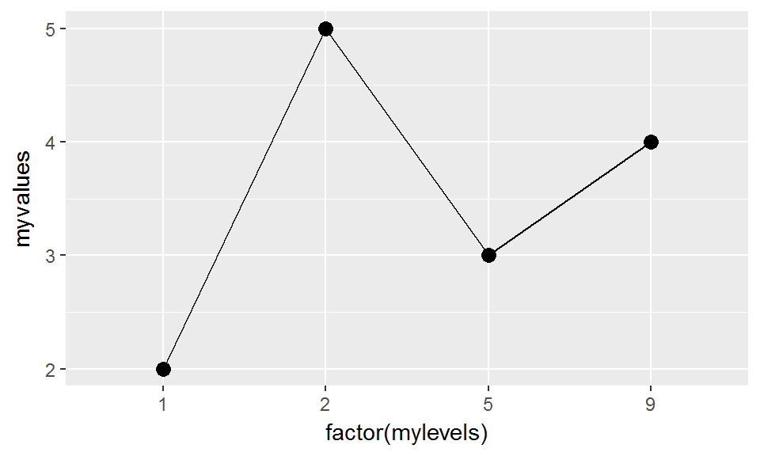

```r
ggplot(dane, aes(x=factor(mylevels), y=myvalues)) + geom_line(group = 1) +
  geom_point(size=3)
```

```
* `geom_line`은 `aes`변수로  `group`을 이용하여 선을 잇는다.
* 참고: `lines()` 함수는 NA를 식별하여 선을 잇는다. (NA가 있는경우 선이 끊어짐)
```

## geom_line

```
* `geom_line`은 시계열 데이터를 표현할 때 자주 이용된다.
* 시계열 데이터에 변수가 2개인 경우 표현방식에 대해 알아본다.
```

## geom_line

```r
data(economics)
data(presidential)
```

```
* 시간에   연속형 변수, 범주형 변수가 대응된다.
    +economics 데이터는 시간에 따른 실업률 정보를 가지고 있다.
    +presidential 데이터는 시간에 따른 집권당의 정보를 가지고 있다.


* ggplot : economics data 에서 x = date, y = unemploy로 두고
`geom_line()`을 적용한다.
```

## geom_line

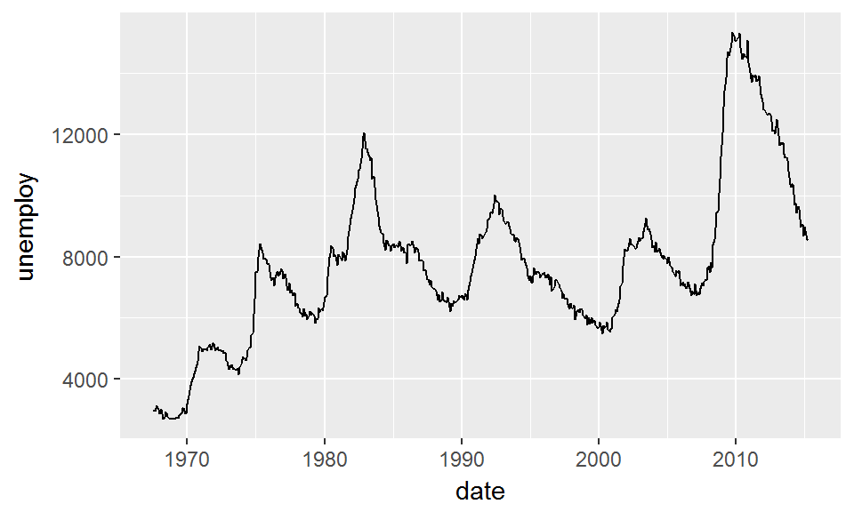

```r
ggplot(economics, aes(date, unemploy)) + geom_line()
```

```
* 날짜별로 집권당의 색깔을 칠한다. `geom_rect` 이용
    * `geom_rect`은 사각형 모양의 그림 객체를 다룬다.
```

## geom_line

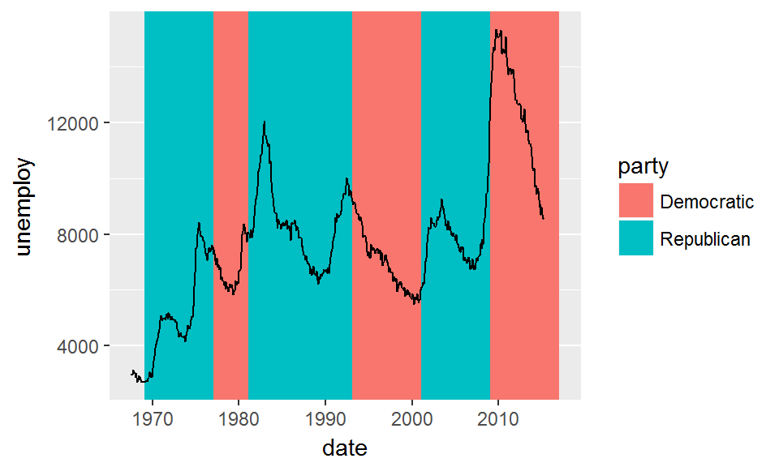

```r
presidential = subset(presidential, start > economics$date[1])
ggplot(economics) + geom_rect(aes(xmin = start,xmax = end, fill = party),
     ymin = -Inf, ymax = Inf, data = presidential) +
     geom_line(aes(date, unemploy), data = economics)
```

## geom_line

- presidential 에서 start가 economics의 date 변수 중 1번째 값보다  
  큰 값을 뽑아 저장한다.
- ggplot :
  - geom_rect : 배경에 직사각형을 그려 xmin, xmax 값등 사용 할 수 있게 해준다.
  - presidential data에서 party별 xmin, xmax값을 start, end로, y값은 제한없이 준다.
  - economics data에서 x축 = date, y축 = unemploy로 준다.

## geom_line

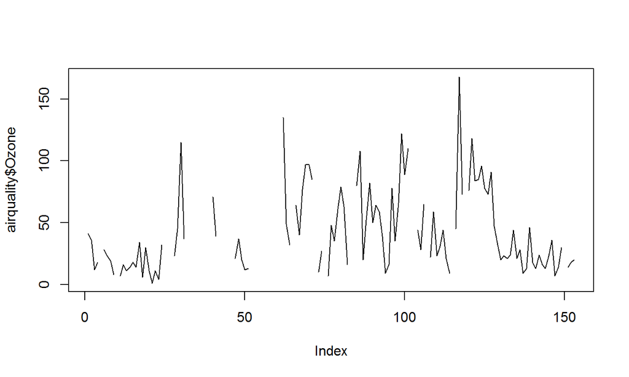

```r
if(!require(datasets)){install.packages("datasets"); library(datasets)}
data(airquality)
plot(airquality$Ozone, type = 'l')
```

## geom_line

```r
aq_trim <- airquality[which(airquality$Month == 7 |
                              airquality$Month == 8 |
                              airquality$Month == 9), ]
aq_trim$Month <- factor(aq_trim$Month,
                        labels = c("July", "August", "September"))
```

## geom_line

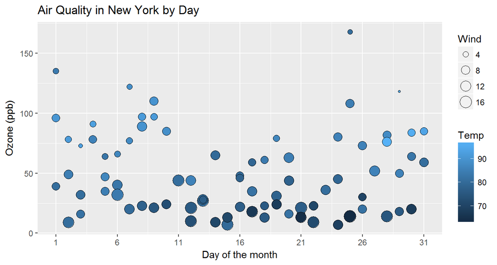

```r
ggplot(aq_trim, aes(x = Day, y = Ozone, size = Wind, fill = Temp)) +
  geom_point(shape = 21) +   ggtitle("Air Quality in New York by Day") +
  labs(x = "Day of the month", y = "Ozone (ppb)") +
  scale_x_continuous(breaks = seq(1, 31, 5))
```

## geom_histogram

```r
festival.data <- read.table(file = 'DownloadFestival.dat',
                            sep = '\t', header = T)
head(festival.data)
```

```
##   ticknumb gender day1 day2 day3
## 1     2111   Male 2.64 1.35 1.61
## 2     2229 Female 0.97 1.41 0.29
## 3     2338   Male 0.84   NA   NA
## 4     2384 Female 3.03   NA   NA
## 5     2401 Female 0.88 0.08   NA
## 6     2405   Male 0.85   NA   NA
```

```
* Data 불러오기
    + read.table을 이용해 외부 data file을 불러들임
    + sep : 구분자 = tab, header : 처음 row가 변수명이면 T 할당
```

## geom_histogram

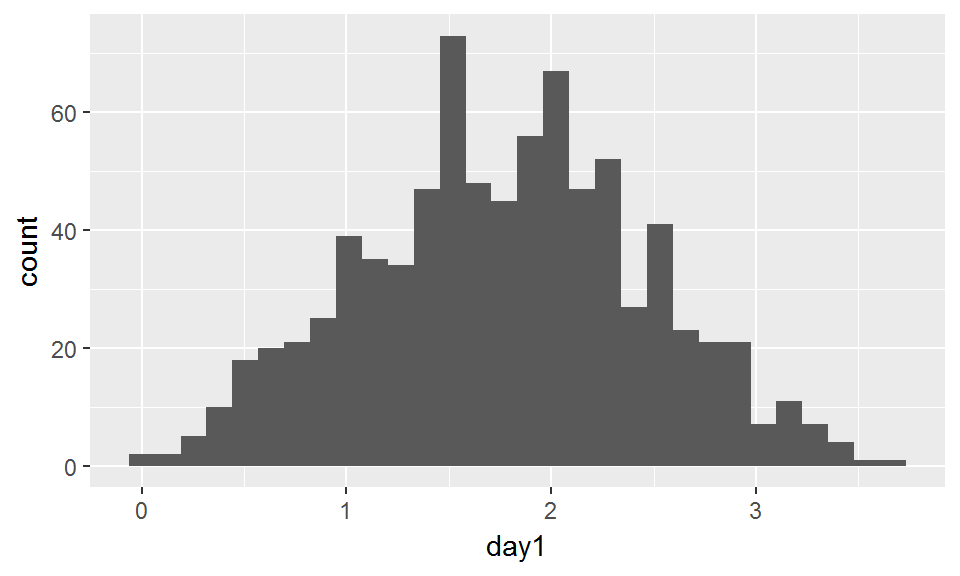

```r
Day1Histogram <- ggplot(data = festival.data, aes( x= day1))
Day1Histogram + geom_histogram()
```

```
* day1의 점수 분포 확인
```

## geom_histogram

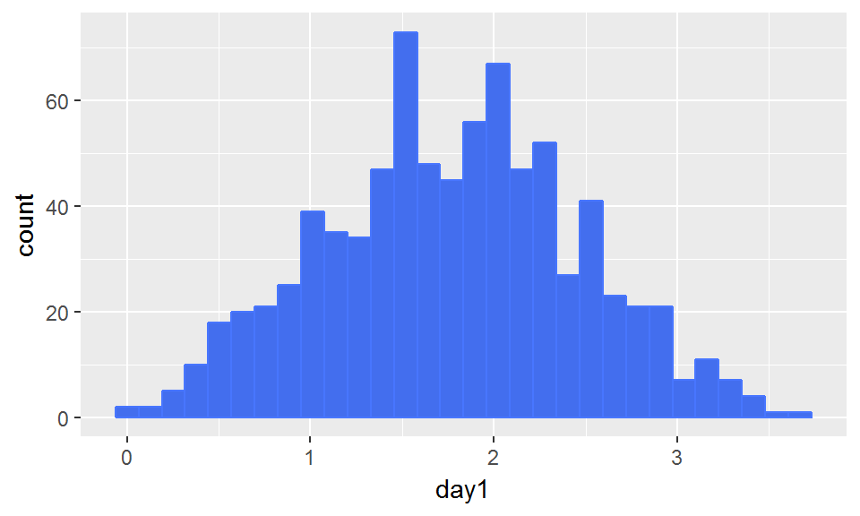

```r
Day1Histogram + geom_histogram(color = 'royalblue1', fill = 'royalblue2')
```

```
* Day1Histogram에
    + 테두리 색깔 = royalblue1을, 그래프 색깔 = royalblue2로 할당
```

## geom_histogram

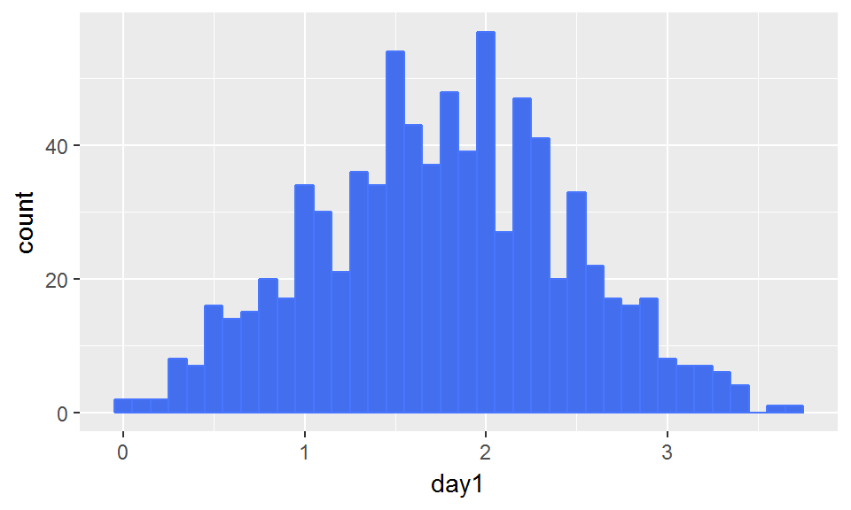

```r
 Day1Histogram + geom_histogram(color = 'royalblue1', fill = 'royalblue2',
                               binwidth  = 0.1)
```

## geom_histogram

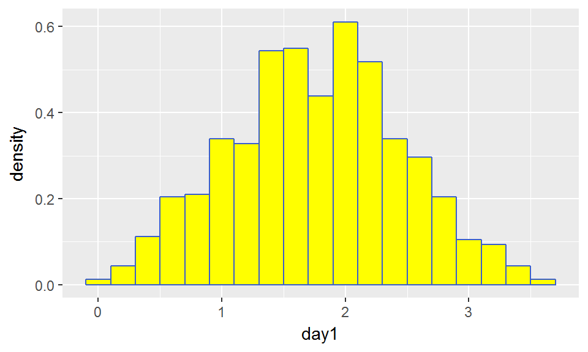

```r
Day1Histogram + geom_histogram(binwidth = 0.2, aes( y = ..density..),
               color= 'royalblue3', fill = 'yellow', bins = 35)
```

```
* aes 내부에 y = ..density..
    + y축을 count가 아닌 밀도로써 표현
```

## geom_histogram

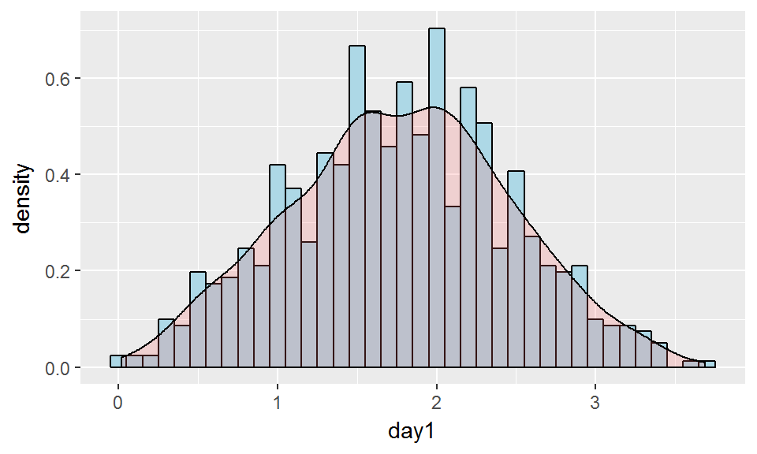

```r
Day1Histogram +geom_histogram(binwidth = 0.1, aes(y=..density..),
              color="black",
              fill="lightblue") + geom_density(alpha=.2, fill="#FF6666")
```

## geom_histogram

```r
festival.data.stack <- melt(festival.data, id = c('ticknumb', 'gender'))
colnames(festival.data.stack)[3:4] <- c('day', 'score')
```

- library(reshape2) 사용
- melt function을 이용한 data handling: data processing 에 reshape2 사용방법 참
- colnames를 이용하여 변수명 지정

## geom_histogram

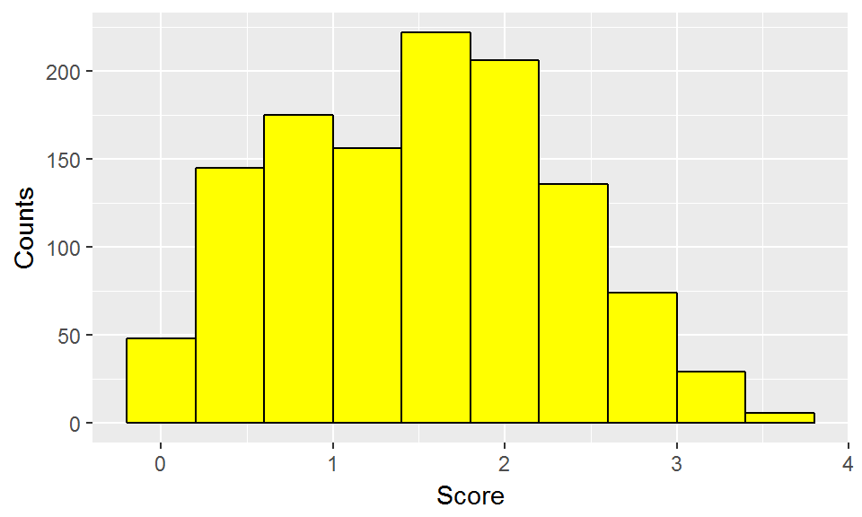

```r
Histogram.3day2 <- ggplot( data = festival.data.stack, aes(x = score)) +
  geom_histogram(binwidth = 0.4, color= 'black', fill = 'yellow') +
  labs( x = 'Score', y = 'Counts')
Histogram.3day2
```

```
* Data를 이용해 histogram 생성
```

## geom_histogram

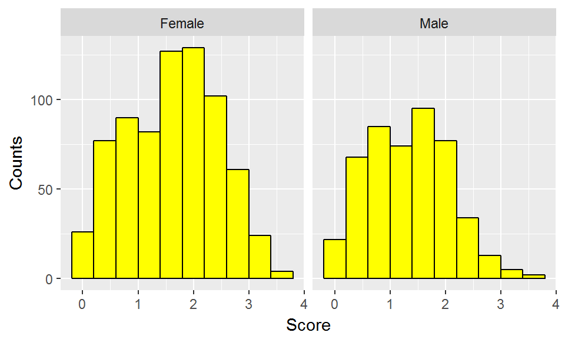

```r
  Histogram.3day2 + facet_grid(~gender)
```

```
* gender별 histogram을 2개 출력
```

## facet_grid

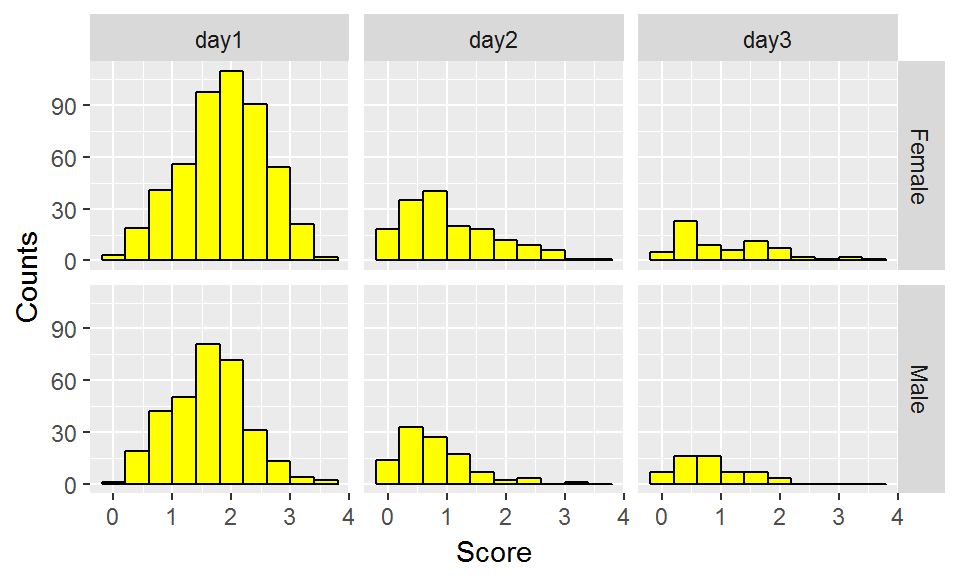

```r
  Histogram.3day2 + facet_grid(gender~day)
```

```
* gender, day별  histogram을 6개 출력
```

- 살펴본 그래프에서 문제점이 무엇인가? 빈도로 히스토그램이 표현되어 분포의 비교가 안된다.

## geom_histogram

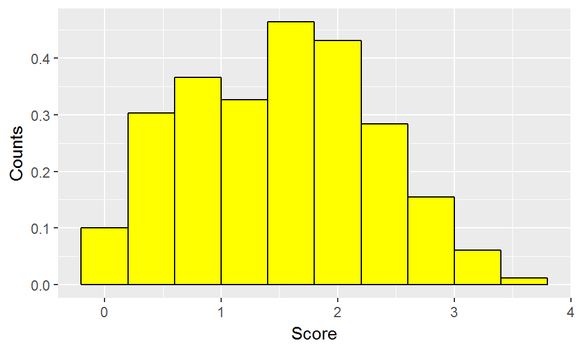

```r
Histogram.3day2 <- ggplot( data = festival.data.stack,
                           aes(x = score, y = ..density..)) +
  geom_histogram(binwidth = 0.4, color= 'black', fill = 'yellow') +
  labs( x = 'Score', y = 'Counts')
Histogram.3day2
```

```
* Data를 이용해 histogram 생성
```

## geom_histogram

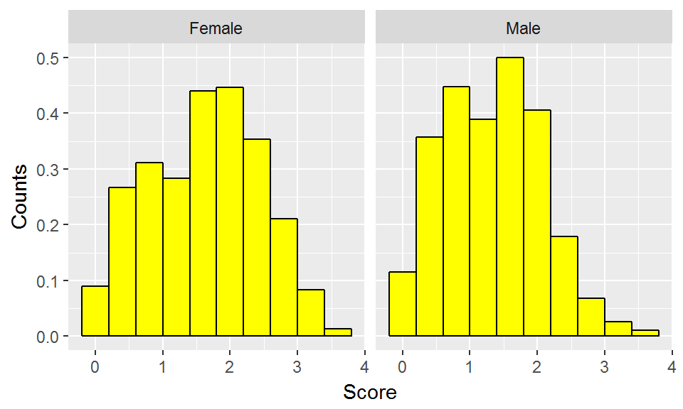

```r
  Histogram.3day2 + facet_grid(~gender)
```

```
* gender별 histogram을 2개 출력
```

## facet_grid

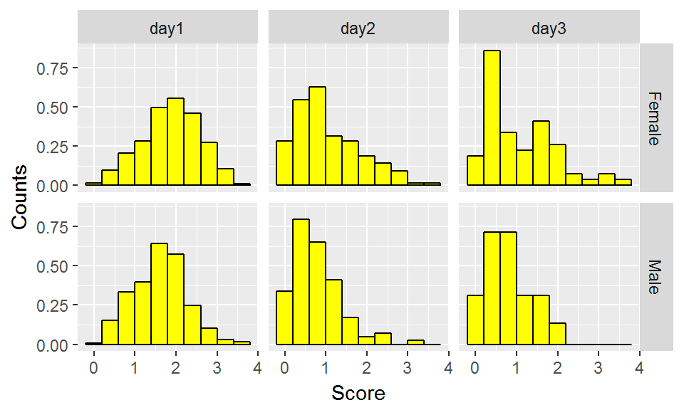

```r
  Histogram.3day2 + facet_grid(gender~day)
```

```
* gender, day별  histogram을 6개 출력
```